# Projet numéro 3 ( exploration )

### Idée de projet

Création d'une application qui donne, pour chacun des produits alimentaire, renvoie les produits les plus diététiques et les meilleurs pour la santé.

### Analyse univariée sur :

- les protéines pour 100 grammes
- le gras pour 100 grammes
- le sucre pour 100 grammes
- le groupe NOVA
- le Nutri-Score
- Nombres d'additifs

### Importons les données néttoyées

```python
import numpy as np
import pandas as pd
import matplotlib.pyplot as plt
import seaborn as sns
```

```python
data = pd.read_csv('data_nettoyer.csv')
```

```python
data.drop(['Unnamed: 0'], axis = 1, inplace = True)
data
```

|  | code | countries_tags | main_category | labels | additives_n | proteins_100g | sugars_100g | fat_100g | nova_group | pnns_groups_1 | nutriscore_grade |
| --- | --- | --- | --- | --- | --- | --- | --- | --- | --- | --- | --- |
| 0 | 0000000274722 | en:france | en:turkey-dishes | Viande Française, Fabriqué en France | 2.0 | 6.80 | 0.50 | 2.20 | 4.0 | Composite foods | b |
| 1 | 0000000491228 | en:france | en:dried-products-to-be-rehydrated | Point Vert | 4.0 | 6.80 | 69.80 | 15.30 | 4.0 | Milk and dairy products | b |
| 2 | 0000009125124 | en:france | en:apple-compotes | Point Vert | 1.0 | 1.50 | 66.00 | 0.50 | 4.0 | Fruits and vegetables | b |
| 3 | 0000009336247 | en:france | en:candies | Contient des OGMs, Sans arômes artificiels | 7.0 | 0.00 | 93.30 | 0.00 | 4.0 | Sugary snacks | d |
| 4 | 0000010206515 | en:france | fr:decorations | Sans gluten | 5.0 | 0.03 | 81.67 | 6.42 | 4.0 | Sugary snacks | d |
| ... | ... | ... | ... | ... | ... | ... | ... | ... | ... | ... | ... |
| 68326 | 9900000000226 | en:france | en:hazelnuts | Bio, Bio européen, IT-BIO-008 | 0.0 | 14.95 | 4.34 | 60.75 | 1.0 | Salty snacks | a |
| 68327 | 9900000001926 | en:france | en:frozen-desserts | Point Vert | 7.0 | 3.00 | 24.00 | 11.00 | 4.0 | unknown | d |
| 68328 | 990530101006053432 | en:france | en:pasteurized-camembert | Bio,Bio européen,AB Agriculture Biologique,FR-... | 0.0 | 17.00 | 1.50 | 24.00 | 3.0 | Milk and dairy products | d |
| 68329 | 99903336 | en:france | en:multifruit-nectars | Organic | 0.0 | 0.50 | 10.00 | 0.00 | 3.0 | Beverages | e |
| 68330 | 9991111111154 | en:france | en:pear-applesauces | Point Vert | 1.0 | 2.00 | 14.00 | 0.20 | 3.0 | Fruits and vegetables | a |

68331 rows × 11 columns

# Pour une analyse univariée :

#### Minimum, maximum, moyenne, médiane, mode, écart type, variance empirique, skewness empirique, kurtosis empirique :

```python
def analyse_uni(data, column):
    print('Minimum :',data[column].min())
    print('Maximum :',data[column].max())
    print('Moyenne :',data[column].mean())
    print('Médiane :',data[column].median())
    print('Mode :',data[column].mode()[0])
    print('Écart type :',data[column].std(ddof=0))
    print('Variance empirique :',data[column].var(ddof=0))
    print('Skewness empirique :',data[column].skew())
    print('Kurtosis empirique :',data[column].kurtosis())
```

#### Boxplot + histogramme

```python
def box_hist(data, column, titre, xlabel, ylabel):
    f, (ax_box, ax_hist) = plt.subplots(2, sharex = True, gridspec_kw={'height_ratios': (.15,.85)},figsize=(12, 8))
    sns.boxplot(data[column], ax=ax_box)
    ax_box.set(xlabel='',title='')
    sns.distplot(data[column], ax=ax_hist)
    plt.title(titre, size=20)
    plt.xlabel(xlabel, size=18)
    plt.ylabel(ylabel,size=18)
    plt.xticks(size=14)
    plt.yticks(size=14)
```

#### Boxplot

```python
def boxplot(data, column, titre, xlabel, ylabel):
    plt.figure(figsize = (12,3))
    sns.set(style='darkgrid')
    sns.boxplot(x = column, data = data)
    plt.title(titre, size = 20)
    plt.xticks(size = 14)
    plt.xlabel(xlabel, size = 14)
    plt.ylabel(ylabel, size=14)
```

#### Graphique de points

```python
def graph(data, column, titre, xlabel, ylabel):
    plt.figure(figsize=(15,6))
    plt.xticks(size=14)
    plt.yticks(size=14)
    plt.xlabel(xlabel,size=14)
    plt.ylabel(ylabel,size=14)
    plt.title(titre,size=18)
    data[column].hist(bins=100)
```

#### Centrons les graphiques à l'aide d'un petit code HTML

```python
from IPython.core.display import HTML
HTML("""
<style>
.output_png {
    display: table-cell;
    text-align: center;
    vertical-align: middle;
}
</style>
""")
```

# Analyses univariées

## Analyse univariée sur les protéines ( Variable quantitative continue )

#### Description du gramme de protéines pour 100g de chaque aliment

```python
data['proteins_100g'].describe()
```

```
count    68331.000000
mean         8.346163
std          8.050967
min          0.000000
25%          2.300000
50%          6.300000
75%         12.000000
max         95.000000
Name: proteins_100g, dtype: float64
```

Les valeurs doivent être comprisent entre 0 et 100. On va donc enlever toutes les erreurs.

```python
print('Il y a :',data[data['proteins_100g']>100]['proteins_100g'].count(),'erreurs supérieur à 100 grammes.')
print('Il y a :',data[data['proteins_100g']<0]['proteins_100g'].count(),'erreurs inférieur à 0 gramme.')
```

```
Il y a : 0 erreurs supérieur à 100 grammes.
Il y a : 0 erreurs inférieur à 0 gramme.
```

```python
data = data[data['proteins_100g']<=100]
data = data[data['proteins_100g']>=0]
```

#### Boxplot + Histogramme

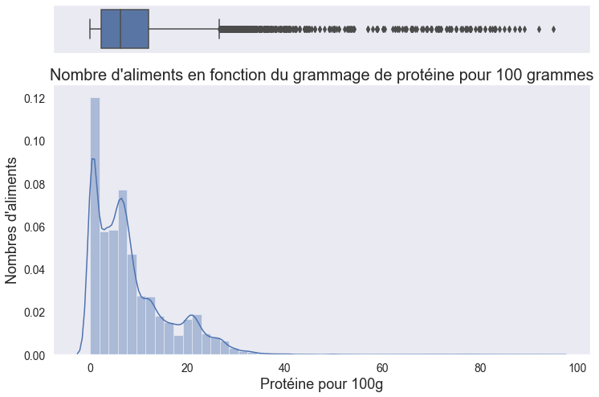

```python
box_hist(data, 'proteins_100g', "Nombre d'aliments en fonction du grammage de protéine pour 100 grammes",
         'Protéine pour 100g', "Nombres d'aliments")
```

##### Vérifions que tous les points qui ne sont pas dans la boîte à moustache ne sont pas des erreurs :

###### Analysons les 10 aliments les plus protéinés

```python
data.sort_values(by = 'proteins_100g').iloc[-10:,:]
```

|  | code | countries_tags | main_category | labels | additives_n | proteins_100g | sugars_100g | fat_100g | nova_group | pnns_groups_1 | nutriscore_grade |
| --- | --- | --- | --- | --- | --- | --- | --- | --- | --- | --- | --- |
| 62879 | 5999076218677 | en:france | en:milks | en:no-lactose | 3.0 | 84.0 | 1.9 | 2.60 | 4.0 | Milk and dairy products | b |
| 61258 | 5056104518571 | en:france | en:artificially-sweetened-beverages | en:gluten-free | 4.0 | 85.0 | 2.4 | 2.40 | 4.0 | Beverages | e |
| 61215 | 5055534325834 | en:france | en:protein-powders | Végétarien, Sans gluten | 2.0 | 86.0 | 2.4 | 0.30 | 4.0 | unknown | b |
| 61206 | 5055534303115 | en:france | en:milks | Bio | 0.0 | 86.0 | 5.4 | 0.30 | 4.0 | Milk and dairy products | b |
| 53039 | 3700153151204 | en:france | en:bodybuilding-supplements | Sans gluten, Point Vert, Riche en protéines | 2.0 | 87.0 | 1.5 | 2.10 | 4.0 | unknown | a |
| 42820 | 3525722021449 | en:france | fr:whey | Sans gluten, Sans OGM, Sans aspartame | 2.0 | 88.0 | 4.5 | 6.90 | 4.0 | unknown | d |
| 4560 | 3 | en:france | en:canned-sardines | Low or no sugar, Low sugar, en:made-in-italy | 0.0 | 88.0 | 8.9 | 1.30 | 3.0 | Fish Meat Eggs | c |
| 875 | 0634065449674 | en:france | en:milks | en:no-lactose | 3.0 | 89.1 | 0.1 | 0.39 | 4.0 | Milk and dairy products | b |
| 66361 | 8436035246014 | en:france | en:milks | fr:entrepreneurs-engages | 2.0 | 92.0 | 0.5 | 1.60 | 4.0 | Milk and dairy products | c |
| 66124 | 8414192309032 | en:france | en:bodybuilding-supplements | Avec édulcorants | 1.0 | 95.0 | 0.2 | 1.20 | 4.0 | unknown | c |

#### Valeurs des paramètres intéressants à l'analyse univariée

```python
analyse_uni(data = data, column = 'proteins_100g')
```

```
Minimum : 0.0
Maximum : 95.0
Moyenne : 8.346162812047602
Médiane : 6.3
Mode : 0.0
Écart type : 8.05090786798774
Variance empirique : 64.8171174988269
Skewness empirique : 1.8730603638293495
Kurtosis empirique : 7.62339981879364
```

##### Ces valeurs nous confirme que le graphique a une distribution:

- étalée à droite ( car Skewness positif )
- moins aplatie que la distribution normale. ( car Kurtosis positif )

#### Que faire des valeurs manquantes ?

Les valeurs qui ne sont pas renseignées, sont soit dû au fait qu'il n'y a pas de protéine dans cet aliment et que donc sa valeur est 0, soit que la valeur n'a pas été rempli. On ne peut le savoir, il est donc plus pertinent de supprimer les lignes dont les valeurs sont manquantes.

## Analyse univariée sur le gras ( Variable quantitative continue )

##### Question : Les aliments du dataset sont ils plutôt gras ?

#### Description du grammage de gras pour 100g de chaque aliment

```python
data['fat_100g'].describe()
```

```
count    68331.000000
mean        13.898350
std         16.398655
min          0.000000
25%          1.700000
50%          7.900000
75%         22.000000
max        100.000000
Name: fat_100g, dtype: float64
```

##### Les valeurs doivent être comprisent entre 0 et 100. On va donc enlever toutes les erreurs.

```python
print('Il y a :',data[data['fat_100g']>100]['fat_100g'].count(),'erreurs supérieur à 100 grammes.')
print('Il y a :',data[data['fat_100g']<0]['fat_100g'].count(),'erreurs inférieur à 0 gramme.')
```

```
Il y a : 0 erreurs supérieur à 100 grammes.
Il y a : 0 erreurs inférieur à 0 gramme.
```

```python
data = data[data['fat_100g']<=100]
data = data[data['fat_100g']>=0]
```

#### Boxplot + Histogramme

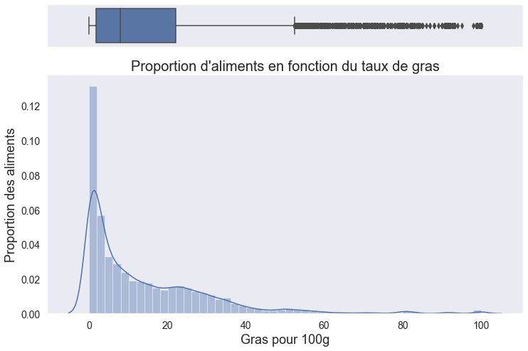

```python
box_hist(data, 'fat_100g', "Proportion d'aliments en fonction du taux de gras",
        'Gras pour 100g',"Proportion des aliments")
sns.set(font_scale=1.2)
```

##### Vérifions que tous les points qui ne sont pas dans la boîte à moustache ne sont pas des erreurs :

```python
data.sort_values(by = 'fat_100g').iloc[-10:,:]
```

|  | code | countries_tags | main_category | labels | additives_n | proteins_100g | sugars_100g | fat_100g | nova_group | pnns_groups_1 | nutriscore_grade |
| --- | --- | --- | --- | --- | --- | --- | --- | --- | --- | --- | --- |
| 26488 | 3266191010540 | en:france | en:extra-virgin-olive-oils | Organic, EU Organic, FR-BIO-01, fr:ab-agricult... | 0.0 | 0.0 | 0.0 | 100.0 | 2.0 | Fat and sauces | c |
| 19708 | 3256221712254 | en:france | en:rapeseed-oils | Point Vert, Conditionné en France, Transformé ... | 0.0 | 0.0 | 0.0 | 100.0 | 2.0 | Fat and sauces | c |
| 19707 | 3256221712247 | en:france | en:corn-oils | Packaged in France,Transformed in France | 0.0 | 0.0 | 0.0 | 100.0 | 2.0 | Fat and sauces | d |
| 19706 | 3256221712230 | en:france | en:sunflower-oils | Point Vert, Conditionné en France, Riche en vi... | 0.0 | 0.0 | 0.0 | 100.0 | 2.0 | Fat and sauces | d |
| 19705 | 3256221712223 | en:france | en:vegetable-oils | Conditionné en France, Transformé en France | 0.0 | 0.0 | 0.0 | 100.0 | 2.0 | Fat and sauces | d |
| 19704 | 3256221712162 | en:france | en:extra-virgin-olive-oils | Point Vert | 0.0 | 0.0 | 0.0 | 100.0 | 2.0 | Fat and sauces | c |
| 62242 | 5412210012967 | en:france | en:sunflower-oils | Point Vert, Eco-Emballages | 0.0 | 0.0 | 0.0 | 100.0 | 2.0 | Fat and sauces | d |
| 19703 | 3256221712056 | en:france | en:mixed-vegetable-oils | Riche en Oméga-3, Omega-3, Conditionné en Fran... | 0.0 | 0.0 | 0.0 | 100.0 | 2.0 | Fat and sauces | c |
| 40268 | 3452013310107 | en:france | en:fats | Bio | 0.0 | 0.0 | 0.0 | 100.0 | 2.0 | Fat and sauces | c |
| 1110 | 0898999007199 | en:france | en:fats | Bio | 0.0 | 0.0 | 0.0 | 100.0 | 2.0 | Fat and sauces | e |

Les 10 aliments les plus gras sont de l'huile, donc ce ne sont pas absolument pas des erreurs. \ Il faut donc les garder sur le boxplot.

#### Valeurs des paramètres intéressants à l'analyse univariée

```python
analyse_uni(data = data, column = 'fat_100g')
```

```
Minimum : 0.0
Maximum : 100.0
Moyenne : 13.898350332936632
Médiane : 7.9
Mode : 0.0
Écart type : 16.39853476329282
Variance empirique : 268.91194238292303
Skewness empirique : 2.013963299602081
Kurtosis empirique : 5.523540821212123
```

###### Ces valeurs nous confirme que le graphique a une distribution:

- étalée à droite
- moins aplatie que la distribution normale.

#### Que faire des valeurs manquantes ?

Les valeurs qui ne sont pas renseignées, sont soit dû au fait qu'il n'y a pas de gras dans cet aliment et que donc sa valeur est 0, soit que la valeur n'a pas été rempli. On ne peut le savoir, il est donc plus pertinent de supprimer les lignes dont les valeurs sont manquantes.

## Analyse univariée sur le sucre ( Variable quantitative continue )

##### Question : Y-a il plus d'aliments sucré ou non sucré ?

#### Description du grammage de sucre pour 100g de chaque aliment

```python
data['sugars_100g'].describe()
```

```
count    68331.000000
mean        12.260437
std         17.451883
min          0.000000
25%          0.900000
50%          3.500000
75%         16.700000
max        100.000000
Name: sugars_100g, dtype: float64
```

###### Les valeurs doivent être comprisent entre 0 et 100. On va donc enlever toutes les erreurs.

```python
print('Il y a :',data[data['sugars_100g']>100]['sugars_100g'].count(),'erreurs supérieur à 100 grammes.')
print('Il y a :',data[data['sugars_100g']<0]['sugars_100g'].count(),'erreurs inférieur à 0 gramme.')
```

```
Il y a : 0 erreurs supérieur à 100 grammes.
Il y a : 0 erreurs inférieur à 0 gramme.
```

```python
data = data[data['sugars_100g'] <= 100]
data = data[data['sugars_100g'] >= 0]
```

#### Boxplot + Histogramme

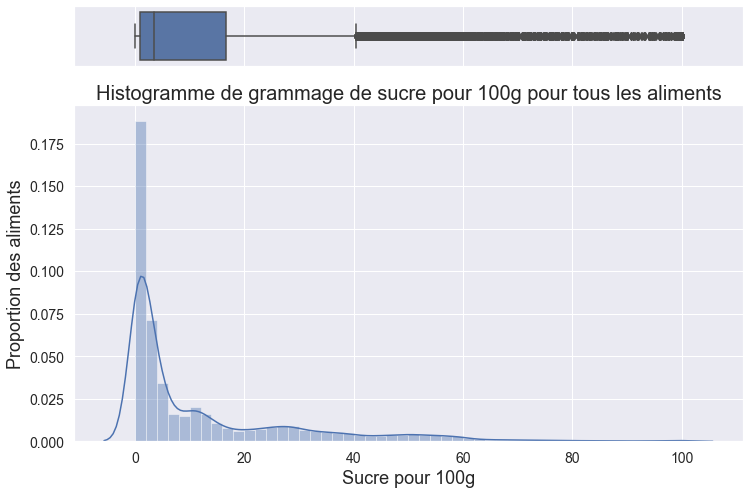

```python
box_hist(data, 'sugars_100g','Histogramme de grammage de sucre pour 100g pour tous les aliments',
        'Sucre pour 100g', 'Proportion des aliments')
```

##### Vérifions que tous les points qui ne sont pas dans la boîte à moustache ne sont pas des erreurs :

```python
data.sort_values(by = 'sugars_100g').iloc[-10:,:]
```

|  | code | countries_tags | main_category | labels | additives_n | proteins_100g | sugars_100g | fat_100g | nova_group | pnns_groups_1 | nutriscore_grade |
| --- | --- | --- | --- | --- | --- | --- | --- | --- | --- | --- | --- |
| 35289 | 3350033419872 | en:france | fr:sucres-mi-blancs | Commerce équitable, Bio, Bio européen, Max Hav... | 0.0 | 0.0 | 100.0 | 0.0 | 2.0 | Sugary snacks | d |
| 7316 | 3071900001111 | en:france | en:lump-sugar | Point Vert,fr:100-agriculture-francaise | 0.0 | 0.0 | 100.0 | 0.0 | 2.0 | Sugary snacks | d |
| 47303 | 3564707091831 | en:france | en:cane-sugar | Bio,Bio européen,AB Agriculture Biologique | 0.0 | 0.0 | 100.0 | 0.0 | 2.0 | Sugary snacks | d |
| 1821 | 20088910 | en:france | fr:sirops-traditionnels | Organic, Vegetarian, Vegan, European Vegetaria... | 0.0 | 0.1 | 100.0 | 0.5 | 1.0 | unknown | d |
| 24730 | 3263850586415 | en:france | en:cane-sugar | Bio,Bio européen,Commerce équitable,Max Havela... | 0.0 | 0.0 | 100.0 | 0.0 | 2.0 | Sugary snacks | d |
| 61441 | 5060380690951 | en:france | en:candies | Végétarien | 1.0 | 0.0 | 100.0 | 0.0 | 4.0 | Sugary snacks | d |
| 10017 | 3174660115804 | en:france | en:lump-sugar | Bio | 0.0 | 0.0 | 100.0 | 0.0 | 2.0 | Sugary snacks | d |
| 10016 | 3174660115750 | en:france | en:lump-sugar | Cultivé et produit en France | 0.0 | 0.0 | 100.0 | 0.0 | 2.0 | Sugary snacks | d |
| 7408 | 3075310120257 | en:france | fr:sucres-perles | Point Vert | 0.0 | 0.0 | 100.0 | 0.0 | 2.0 | Sugary snacks | d |
| 10002 | 3174660032316 | en:france | en:lump-sugar | La Perruche PURE CANNE | 0.0 | 0.0 | 100.0 | 0.0 | 2.0 | Sugary snacks | d |

Les produits les plus sucrés sont du sucre en poudre, cela est donc pertinent. \ Les aliments contenant 100% de sucre ne sont donc pas des erreurs.

#### Valeurs des paramètres intéressants à l'analyse univariée

```python
analyse_uni(data = data, column = 'sugars_100g')
print('Il y a',data[data['sugars_100g']==0]['sugars_100g'].count(),"aliments non sucré.")
```

```
Minimum : 0.0
Maximum : 100.0
Moyenne : 12.260436516344457
Médiane : 3.5
Mode : 0.5
Écart type : 17.451755483916497
Variance empirique : 304.56376947040945
Skewness empirique : 1.9385360757997585
Kurtosis empirique : 3.7121399078407014
Il y a 4609 aliments non sucré.
```

###### Ces valeurs nous confirme que le graphique a une distribution:

- étalée à droite
- moins aplatie que la distribution normale.

#### Que faire des valeurs manquantes ?

Les valeurs qui ne sont pas renseignées, sont soit dû au fait qu'il n'y a pas de sucre dans cet aliment et que donc sa valeur est 0, soit que la valeur n'a pas été rempli. On ne peut le savoir, il est donc plus pertinent de supprimer les lignes dont les valeurs sont manquantes.

## Analyse univariée sur l'indicateur NOVA ( Variable qualitative ordinale )

- Groupe 1 : Aliments non transformés ou transformés minimalement
- Groupe 2 : Ingrédients culinaires transformés
- Groupe 3 : Aliments transformés
- Groupe 4 : Produits alimentaires et boissons ultra-transformés

##### Question : Les produits de ce dataset sont plutôt transformés ou plutôt non transformés ?

```python
data['nova_group'].describe()
```

```
count    68331.000000
mean         3.354466
std          0.980876
min          1.000000
25%          3.000000
50%          4.000000
75%          4.000000
max          4.000000
Name: nova_group, dtype: float64
```

```python
data['nova_group'].unique()
```

```
array([4., 3., 1., 2.])
```

Il n'y a pas d'erreurs de remplissages.

#### Diagramme à barre

Mettre les valeurs en chaîne de caractère :

```python
data['nova_group'] = data['nova_group'].astype(int)
data['nova_group'] = data['nova_group'].astype(str)
```

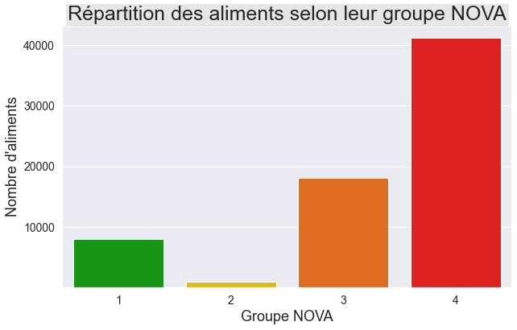

```python
plt.figure(figsize = (10,6 ))
x = data["nova_group"].value_counts(normalize=True).sort_index(axis = 0, ascending = True)
sns.countplot(data = data, x = 'nova_group', order = ['1','2','3','4'], palette = ['#01aa01','#ffcc00','#ff6502','#fd0100'])
plt.ylabel("Nombre d'aliments",size=18)
plt.yticks([10000,20000,30000,40000],size=14)
plt.xticks(size=14)
plt.xlabel("Groupe NOVA",size=18)
plt.title('Répartition des aliments selon leur groupe NOVA',size=25,bbox={'facecolor':'0.9', 'pad':3})
```

```python
print(int(data[data['nova_group'] == '4'].shape[0]*10000/data.shape[0])/100,'% de produits de groupe NOVA 4.' )
```

```
60.36 % de produits de groupe NOVA 4.
```

```python
data[data['nova_group']=='1'].shape[0]
```

```
8029
```

#### Que faire des valeurs manquantes ?

NOVA étant un point important pour l'application, il est préférable de supprimer les lignes dont le groupe NOVA est manquant.

## Analyse univariée sur le Nutri Score ( Variable qualitative ordinale )

- Classe A : du produit le plus favorable sur le plan nutritionnel
- Classe E : au produit le moins favorable sur le plan nutritionnel

##### Les produits sont-ils plus ou moins favorable sur le plan nutritionnel ?

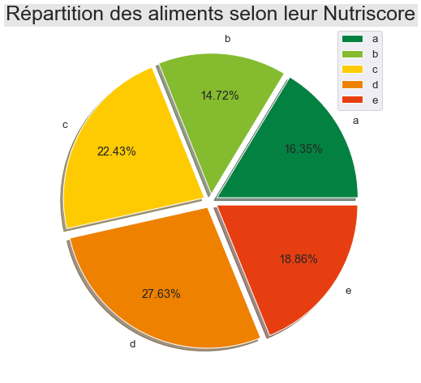

```python
plt.figure(figsize = (8, 8))
x = data["nutriscore_grade"].value_counts(normalize=True).sort_index(axis = 0, ascending = True)
plt.pie(x, labels = ['a', 'b', 'c', 'd','e'],
            colors = ['#038141','#85bb2f','#fecb02','#ee8100','#e63e11'],
           explode = [0.05, 0.05, 0.05, 0.05, 0.05],
           autopct = lambda x: str(round(x, 2)) + '%',
           pctdistance = 0.7, labeldistance = 1.1,
           shadow = True)
plt.legend()
plt.title('Répartition des aliments selon leur Nutriscore',size=25,bbox={'facecolor':'0.9', 'pad':3})
```

## Analyse univariée sur le nombre d'additifs

Variable quantitative discrète

##### Question : Quelles est la moyenne du nombre d'additifs dans un produit ?

#### Diagramme en barre ( tuyaux d'orgues )

```python
data['additives_n'] = data['additives_n'].astype(int)
```

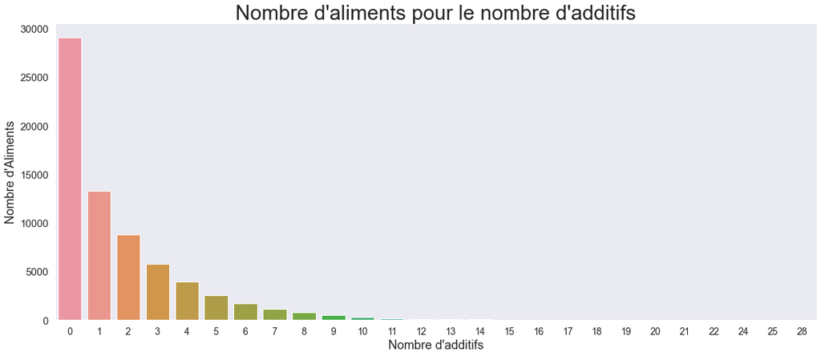

```python
plt.figure(figsize=(20,8))
sns.set(style='dark')
sns.countplot(x='additives_n',data=data)
plt.xticks(size=14)
plt.yticks(size=15)
plt.xlabel("Nombre d'additifs",size=18)
plt.ylabel("Nombre d'Aliments",size=18)
plt.title("Nombre d'aliments pour le nombre d'additifs",size=30)
```

```python
print(int(data[data['additives_n']==0].shape[0]*10000/data.shape[0])/100,"% de produits n'ont pas d'additifs.")
```

```
42.52 % de produits n'ont pas d'additifs.
```

```python
analyse_uni(data = data, column = 'additives_n')
```

```
Minimum : 0
Maximum : 28
Moyenne : 1.692028508290527
Médiane : 1.0
Mode : 0
Écart type : 2.3116022827827423
Variance empirique : 5.343505113766384
Skewness empirique : 2.1402307273947248
Kurtosis empirique : 6.586008135422029
```

```python
print('Il y a',int(data[data['additives_n'] == 0].shape[0]*10000/data.shape[0])/100,"% de produits alimentaires qui n'ont pas d'additifs.")
```

```
Il y a 42.52 % de produits alimentaires qui n'ont pas d'additifs.
```

En moyenne, un produit a 1,7 additifs.

#### Que faire des valeurs manquantes

Le nombre d'additifs est important pour notre application. \ Les valeurs qui ne sont pas renseignées, sont soit dû au fait qu'il n'y a pas d'additifs dans cet aliment et que donc sa valeur est 0, soit que la valeur n'a pas été rempli. \ Donc il est préférable de supprimer les lignes dont les valeurs sont manquantes.

```python
data[data['additives_n'] == 22]
```

|  | code | countries_tags | main_category | labels | additives_n | proteins_100g | sugars_100g | fat_100g | nova_group | pnns_groups_1 | nutriscore_grade |
| --- | --- | --- | --- | --- | --- | --- | --- | --- | --- | --- | --- |
| 28868 | 3270720013704 | en:france | en:confectioneries | Conditionné en France | 22 | 3.7 | 68.0 | 6.5 | 4 | Sugary snacks | c |
| 41694 | 3497391000301 | en:france | en:chocolate-cakes | Point Vert, Fabriqué dans l'UE | 22 | 4.9 | 33.0 | 24.0 | 4 | Sugary snacks | e |
| 47946 | 3567741001071 | en:france | fr:eclairs | Avec édulcorants | 22 | 3.2 | 21.0 | 10.0 | 4 | Sugary snacks | d |
| 63077 | 7290005431401 | en:france | en:frozen-cakes-and-pastries | Kascher, Kasher LePessah | 22 | 1.9 | 21.0 | 14.7 | 4 | Sugary snacks | d |
| 66229 | 8425252156305 | en:france | en:protein-bars | Riche en protéines, Sans sucre ajouté, Sans hu... | 22 | 24.2 | 0.5 | 7.2 | 4 | unknown | d |
| 66451 | 8437012185300 | en:france | en:ham-sandwiches | Point Vert | 22 | 10.2 | 1.9 | 5.5 | 4 | Composite foods | c |

# Analyses bivariées

## Analyse bivariée entre le Nutri Score et NOVA

2 variables qualitatives ordinales

##### Question : Un produit transformé a-t-il même qualité nutrionnelle qu'un produit non transformé ?

#### Tableau de contingence

```python
X = 'nova_group'
Y = 'nutriscore_grade'

c = data[[X,Y]].pivot_table(index=X,columns=Y,aggfunc=len)
cont = c.copy()

tx = data[X].value_counts()
ty = data[Y].value_counts()

cont.loc[:,'Total'] = tx
cont.loc["Total",:] = ty
cont.loc["Total","Total"] = len(data)
cont
```

| nutriscore_grade nova_group | a | b | c | d | e | Total |
| --- | --- | --- | --- | --- | --- | --- |
| 1 | 4369.0 | 1289.0 | 1526.0 | 620.0 | 225.0 | 8029.0 |
| 2 | 7.0 | 5.0 | 282.0 | 273.0 | 399.0 | 966.0 |
| 3 | 3124.0 | 2584.0 | 3412.0 | 5821.0 | 3150.0 | 18091.0 |
| 4 | 3673.0 | 6181.0 | 10109.0 | 12169.0 | 9113.0 | 41245.0 |
| Total | 11173.0 | 10059.0 | 15329.0 | 18883.0 | 12887.0 | 68331.0 |

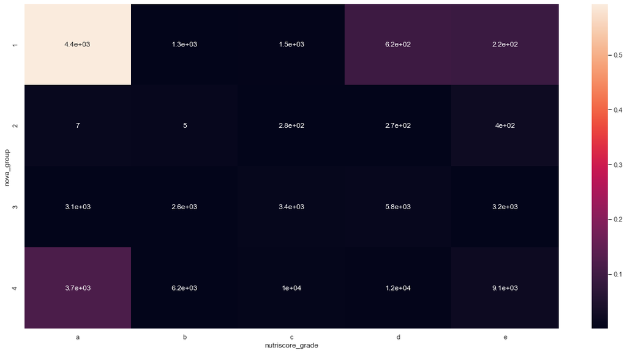

```python
tx=cont.loc[:,['Total']]
ty=cont.loc[['Total'],:]
n=len(data)
indep = tx.dot(ty) / n

c = cont.fillna(0)
mesure = (c-indep)**2/indep
sum_m = mesure.sum().sum()
table = mesure/sum_m
plt.figure(figsize=(20,10))
sns.heatmap(table.iloc[:-1,:-1],annot=c.iloc[:-1,:-1])
plt.show()
```

#### Graphique à barres

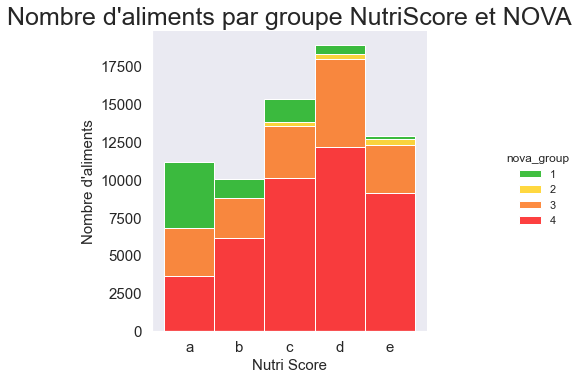

```python
sns.displot(data = data_nutriscore, x="nutriscore_grade", hue="nova_group", multiple="stack", hue_order=['1','2','3','4'], palette=['#01aa01','#ffcc00','#fd6602','#fd0000'])
plt.title("Nombre d'aliments par groupe NutriScore et NOVA", size=25)
plt.xticks(size=15)
plt.yticks(size=15)
plt.ylabel("Nombre d'aliments", size=15)
plt.xlabel('Nutri Score', size=15)
```

## Analyse bivariée entre le sucre et le gras

2 variables quantitatives continue

##### Question : Est ce qu'un produit alimentaire très sucré est forcément gras ?

```python
a = data['sugars_100g']
b = data['fat_100g']
```

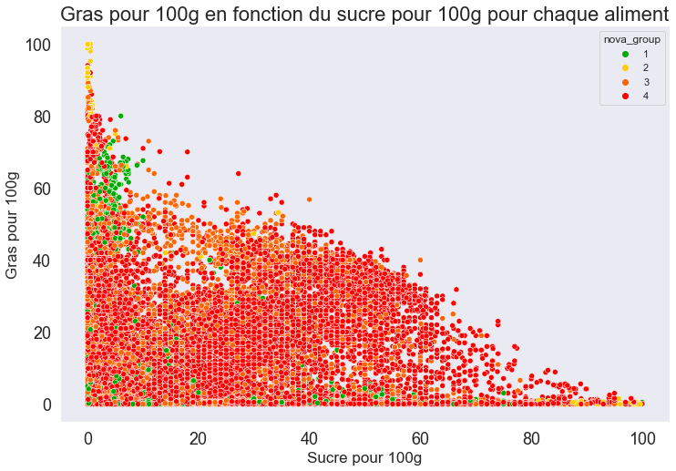

```python
plt.figure(figsize = (12,8))
plt.title('Gras pour 100g en fonction du sucre pour 100g pour chaque aliment',size=22)
plt.xlabel('Sucre pour 100g', size=17)
plt.ylabel('Gras pour 100g', size=17)
plt.xticks(size=18)
plt.yticks(size=18)
sns.scatterplot(x=data['sugars_100g'], y=data['fat_100g'], hue='nova_group', hue_order=['1','2','3','4'],data=data, palette=['#01aa01','#ffcd00','#ff6502','#fd0000'])
plt.show()
```

```python
import scipy.stats as st
```

#### Coefficient de corrélation de Pearson

```python
st.pearsonr(a,b)[0]
```

```
-0.012737800654569859
```

###### Aucune corrélation entre le sucre et le gras

## Analyse bivariée entre le taux de sucre et le Nutri Score Grade

Variable quantitative continue et variable qualitative ordinale

##### Question : Un produit sucré est-il forcément de mauvaise qualité nutritionnelle ?

```python
a = data[data['nutriscore_grade'] == 'a'].copy()
b = data[data['nutriscore_grade'] == 'b'].copy()
c = data[data['nutriscore_grade'] == 'c'].copy()
d = data[data['nutriscore_grade'] == 'd'].copy()
e = data[data['nutriscore_grade'] == 'e'].copy()
data_nutriscore = pd.concat([a,b,c,d,e])
```

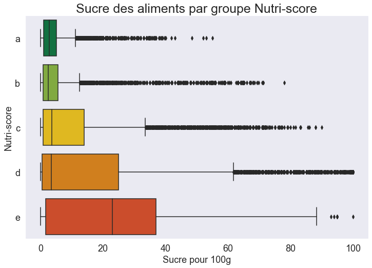

```python
plt.figure(figsize=(12,8))
sns.boxplot(data = data_nutriscore, x = 'sugars_100g', y = 'nutriscore_grade', palette=['#038141','#85bb2f','#fecb02','#ee8100','#e63e11'])
plt.xticks(size=18)
plt.yticks(size=18)
plt.xlabel('Sucre pour 100g',size=18)
plt.ylabel('Nutri-score',size=18)
plt.title('Sucre des aliments par groupe Nutri-score',size=25)
```

#### Test du rapport de corrélation

```python
X = "nutriscore_grade" # qualitative
Y = "sugars_100g" # quantitative

def eta_squared(x,y):
    moyenne_y = y.mean()
    classes = []
    for classe in x.unique():
        yi_classe = y[x==classe]
        classes.append({'ni': len(yi_classe),
                        'moyenne_classe': yi_classe.mean()})
    SCT = sum([(yj-moyenne_y)**2 for yj in y])
    SCE = sum([c['ni']*(c['moyenne_classe']-moyenne_y)**2 for c in classes])
    return SCE/SCT

eta_squared(data[X],data[Y])
```

```
0.13505089809199824
```

# Analyse sur le Bio

```python
nb = 0
for i in range(data.shape[0]):
    if 'bio' in data['labels'][i] or 'Bio' in data['labels'][i] or 'BIO' in data['labels'][i]:
        nb +=1

print('Il y a',int(nb*1000/data.shape[0])/10,'% (16134 / 68331) de produits alimentaire qui sont bio dans le dataset nettoyé.')
```

```
Il y a 23.6 % (16134 / 68331) de produits alimentaire qui sont bio dans le dataset nettoyé.
```

# Algorithme qui détermine le meilleur produit alimentaire

```python
def best_food(aliment):

    df = data[data['main_category'] == aliment].copy()
    index = df.index

    # Commençons par le bio :

    for i in index:
        if ('bio' and 'Bio' and 'BIO') not in df['labels'][i]:
            df.drop(i, inplace =True)
    produit_bio = True
    if df.shape[0] == 0:
        df = data[data['main_category'] == aliment].copy()
        produit_bio = False


    # Choix du meilleur Nutri Score :

    for i in ['a','b','c','d','e']:
        if df[df['nutriscore_grade'] == i].shape[0] != 0: # On peut aussi utiliser le nutri score entre -15 et 40
            df = df[df['nutriscore_grade'] == i]
            break


    # Choix du meilleur groupe NOVA :

    for i in range (1,5):
        if df[df['nova_group'] == i].shape[0] != 0:
            df = df[df['nova_group'] == i]
            break


    # Le moins d'additifs possible :

    nb_add_min = df['additives_n'].min()
    df = df[df['additives_n'] == nb_add_min]


    # Le moins de sucre possible :

    g_sugars_min = df['sugars_100g'].min()
    df = df[df['sugars_100g'] == g_sugars_min]


    # Le moins de graisse possible :

    g_fat_min = df['fat_100g'].min()
    df = df[df['fat_100g'] == g_fat_min]

    # Si le groupe Nova est égal à 4, le produit est mauvais

    if int(df['nova_group']) == 4 :
        print('Cet aliment est mauvais pour la santé (groupe nova 4). À éviter !')

    print("Le code du produit est :",int(df['code']))
    if produit_bio:
        print("Le produit est bio")
    else:
        print("Le produit n'est pas bio")
    print("Le Nutri-score est :",df.iloc[0,-1],"")
    print("Le groupe Nova est :",int(df['nova_group']))
    print("Il y a",int(df['additives_n']),'additifs dans ce produit')
    print("Le taux de sucre dans le produit est de :",float(df['sugars_100g']),"%")
    print("Le taux de gras dans le produit est de :",float(df['fat_100g']),"%")

    return df
```

## Prenons des exemples :

#### Pistaches salées

```python
best_food('fr:pistaches-salees')
```

```
Le code du produit est : 3258561120782
Le produit est bio
Le Nutri-score est : b
Le groupe Nova est : 3
Il y a 0 additifs dans ce produit
Le taux de sucre dans le produit est de : 6.5 %
Le taux de gras dans le produit est de : 49.0 %
```

|  | code | countries_tags | main_category | labels | additives_n | proteins_100g | sugars_100g | fat_100g | nova_group | pnns_groups_1 | nutriscore_grade |
| --- | --- | --- | --- | --- | --- | --- | --- | --- | --- | --- | --- |
| 23320 | 3258561120782 | en:france | fr:pistaches-salees | Bio,Bio européen,AB Agriculture Biologique,FR-... | 0 | 25.0 | 6.5 | 49.0 | 3 | Salty snacks | b |

#### Ketchup

```python
best_food('en:ketchup')
```

```
Le code du produit est : 3700663000474
Le produit est bio
Le Nutri-score est : b
Le groupe Nova est : 3
Il y a 0 additifs dans ce produit
Le taux de sucre dans le produit est de : 11.6 %
Le taux de gras dans le produit est de : 1.0 %
```

|  | code | countries_tags | main_category | labels | additives_n | proteins_100g | sugars_100g | fat_100g | nova_group | pnns_groups_1 | nutriscore_grade |
| --- | --- | --- | --- | --- | --- | --- | --- | --- | --- | --- | --- |
| 53892 | 3700663000474 | en:france | en:ketchup | Bio,Bio européen,Végétarien,Sans gluten,Végéta... | 0 | 1.4 | 11.6 | 1.0 | 3 | Fat and sauces | b |

#### Pates chinoises

```python
best_food('en:chinese-noodles')
```

```
Le code du produit est : 3386030001598
Le produit n'est pas bio
Le Nutri-score est : a
Le groupe Nova est : 3
Il y a 0 additifs dans ce produit
Le taux de sucre dans le produit est de : 2.1 %
Le taux de gras dans le produit est de : 3.2 %
```

|  | code | countries_tags | main_category | labels | additives_n | proteins_100g | sugars_100g | fat_100g | nova_group | pnns_groups_1 | nutriscore_grade |
| --- | --- | --- | --- | --- | --- | --- | --- | --- | --- | --- | --- |
| 37302 | 3386030001598 | en:france | en:chinese-noodles | Sans exhausteur de goût, Sans colorants, Sans ... | 0 | 7.6 | 2.1 | 3.2 | 3 | Cereals and potatoes | a |

#### Desserts glacés

```python
best_food('en:frozen-desserts')
```

```
Cet aliment est mauvais pour la santé (groupe nova 4). À éviter !
Le code du produit est : 4260290870226
Le produit est bio
Le Nutri-score est : b
Le groupe Nova est : 4
Il y a 2 additifs dans ce produit
Le taux de sucre dans le produit est de : 19.5 %
Le taux de gras dans le produit est de : 5.7 %
```

|  | code | countries_tags | main_category | labels | additives_n | proteins_100g | sugars_100g | fat_100g | nova_group | pnns_groups_1 | nutriscore_grade |
| --- | --- | --- | --- | --- | --- | --- | --- | --- | --- | --- | --- |
| 60488 | 4260290870226 | en:france | en:frozen-desserts | Bio, Bio européen, Sans gluten, NL-BIO-01 | 2 | 3.8 | 19.5 | 5.7 | 4 | unknown | b |